← Eğitim Listesine Geri Dön

# Değişken Nedir?

2025-05-23

değişken türler veri yapısı

# 📊 Değişken Nedir? Sayıların Anlamına Giden Yol

## Giriş: Her Birim Farklı mı?

Diyelim ki bir sınıftaki öğrencilerin notlarını incelemek istiyorsun.  
Her öğrenci farklı çalışmış, farklı puan almış.  
Bu farkları nasıl tanımlarız?

👉 İşte burada devreye **değişkenler** girer.  
Birimler arasında değişen her şey, bir değişkendir.

> “Değişken, veri dünyasında ‘farklılık’ kavramının ta kendisidir.”

## 🔍 Değişken Nedir?

**Değişken**, gözlemden gözleme farklı değerler alabilen özelliğe denir.

Değişken Nedir? Tanım: Bir popülasyon veya örneklemde ölçülebilen veya sayılabilen her özelliği temsil eden semboldür.

Örnek: Yaş, gelir, cinsiyet, boy uzunluğu.

📌 Örneğin:

- Yaş → sayısal, sürekli
- Cinsiyet → kategorik, nitel
- Satış adedi → sayılabilir, kesikli

## 🧠 Neden Değişkenleri Tanımak Önemlidir?

| Sebep | Açıklama |
| --- | --- |
| ✅ Veri Türü Belirleme | Hangi işlem yapılacağına karar verir |
| ✅ Modelleme Yaklaşımı | Lojistik regresyon mu? Lineer mi? |
| ✅ Görselleştirme | Histogram mı, kutu grafiği mi? Pasta grafiği mi? |
| ✅ İstatistiksel Test Seçimi | Korelasyon, hipotez testi, vs. |

📌 Değişken türü bilmek, analiz yolunu belirler.

```python
import numpy as np
import pandas as pd

np.random.seed(42)

n = 1000  # gözlem sayısı
data = {
    "fiyat": np.round(np.random.uniform(low=50, high=500, size=n), 2),
    "satis_adedi": np.random.randint(1, 20, size=n),
    "kategori": np.random.choice(['Elektronik', 'Giyim', 'Ev Eşyası'], size=n)
}

df = pd.DataFrame(data)
print(df.head())
```

```
    fiyat  satis_adedi    kategori
0  218.54           15       Giyim
1  477.82           12  Elektronik
2  379.40           16   Ev Eşyası
3  319.40           19       Giyim
4  120.21            8       Giyim
```

```python
df.to_csv("data/istatistik_ornek.csv", index=False)
print("Sample veri oluşturuldu: istatistik_ornek.csv")
```

```
Sample veri oluşturuldu: istatistik_ornek.csv
```

## 📐 Değişken Türleri: Yapılarına Göre

### 1. **Nitel (Qualitative) Değişkenler**

Kaliteyi gösterir, miktar değil.

| Tür | Açıklama | Örnek |
| --- | --- | --- |
| **Nominal** | Sıra yok | Cinsiyet, milliyet |
| **Ordinal** | Sıralı ama eşit aralıklı değil | Memnuniyet skoru: kötü, iyi, çok iyi |

#### Python Kodu:

```python
print("Örnek Nitel Değişken:", df['kategori'].unique())
```

```
Örnek Nitel Değişken: ['Giyim' 'Elektronik' 'Ev Eşyası']
```

✅ `Elektronik`, `Giyim`, `Ev Eşyası` → nitel değişkenlerdir

Nitel (Kalitatif) Değişkenler

Özellik: Kategorik değerler alır, sınıflandırma yapılır.

Alt Türler:

Nominal (Adlandırma): Sıralama yok (örnek: cinsiyet, renk).

Ordinal (Sıralı): Derecelendirme var (örnek: eğitim seviyesi, memnuniyet skalası).

Örnekler: Medeni durum, kan grubu.

Değerlerine Göre

Sürekli Değişkenler

Özellik: Ölçümle belirlenir, kesirli değerler alabilir.

Örnek: Boy (172.5 cm), sıcaklık (36.7°C).

Kesikli Değişkenler

Özellik: Sayma ile belirlenir, tam sayı değerler alır.

Örnek: Araba sayısı, doğum sayısı.

### 2. **Nicel (Quantitative) Değişkenler**

Sayılarla ifade edilebilir. Ölçülebilir ya da sayılabilir.

| Tür | Açıklama | Örnek |
| --- | --- | --- |
| **Kesikli (Discrete)** | Sayılabilir | Çocuk sayısı, sipariş adedi |
| **Sürekli (Continuous)** | Ölçülebilir | Boy, gelir, sıcaklık |

#### Python Kodu:

```python
print("Ortalama fiyat:", df['fiyat'].mean().round(2))
print("Satış adedi ortalaması:", df['satis_adedi'].mean())
```

```
Ortalama fiyat: 270.62
Satış adedi ortalaması: 9.926
```

📌 `fiyat` → sürekli  
`satis_adedi` → kesikli

Nicel (Kantitatif) Değişkenler

Özellik: Sayısal değer alır, ölçülebilir veya tartılabilir.

Alt Türler:

Sürekli Değişken: Sonsuz ara değer alabilir (örnek: boy, ağırlık, sıcaklık).

Kesikli Değişken: Tam sayı değerler alır (örnek: çocuk sayısı, hata sayısı).

Örnekler: Yaş, maaş, sınav puanı.

## 📈 Bağımlı mı? Bağımsız mı?

| Tür | Açıklama | Örnek |
| --- | --- | --- |
| **Bağımlı Değişken (Y)** | Tahmin edilmek istenen değişken | Maaş |
| **Bağımsız Değişken (X)** | Tahmin etmek için kullanılan değişkenler | Tecrübe, eğitim yılı |

📌 Bu ayrım, regresyon ve makine öğrenmesinde hayati öneme sahiptir.

Neden-Sonuç İlişkisine Göre

Bağımsız Değişken (Açıklayıcı Değişken)

Tanım: Bağımlı değişkeni etkileyen faktör.

Örnek: Eğitim süresi (maaşı etkiler).

Bağımlı Değişken (Yanıt Değişkeni)

Tanım: Bağımsız değişkene bağlı olarak değişen sonuç.

Örnek: Maaş (eğitim süresine bağlı).

## 📦 Gerçek Hayat Senaryoları

| Senaryo | Bağımlı Değişken | Bağımsız Değişken(ler) |
| --- | --- | --- |
| Müşteri memnuniyeti tahmini | Memnuniyet skoru | Ürün kalitesi, hizmet süresi |
| Satış tahmini | Satış adedi | Reklam bütçesi, fiyat |
| Maaş modeli | Maaş | Tecrübe, eğitim yılı, şehir |
| Kalite kontrolü | Uygunluk | Sıcaklık, üretim hızı |

📌 Amacımız:  
**Bağımlı değişkeni etkileyen en güçlü bağımsız değişkenleri bulmak.**

## 🛠️ Sample Veri Üzerinden Bakalım

Elimizdeki sample veri şu şekildeydi:

```python
df
```

|  | fiyat | satis_adedi | kategori |
| --- | --- | --- | --- |
| 0 | 218.54 | 15 | Giyim |
| 1 | 477.82 | 12 | Elektronik |
| 2 | 379.40 | 16 | Ev Eşyası |
| 3 | 319.40 | 19 | Giyim |
| 4 | 120.21 | 8 | Giyim |
| ... | ... | ... | ... |
| 995 | 91.21 | 4 | Ev Eşyası |
| 996 | 462.79 | 14 | Ev Eşyası |
| 997 | 111.57 | 9 | Ev Eşyası |
| 998 | 477.61 | 9 | Ev Eşyası |
| 999 | 250.70 | 18 | Elektronik |

1000 rows × 3 columns

📌 Bu veriyle birkaç değişken tanımı yapalım:

| Değişken | Tür | Açıklama |
| --- | --- | --- |
| `fiyat` | Nicel, Sürekli | Ürün fiyatı |
| `satis_adedi` | Nicel, Kesikli | Ne kadar satıldığını gösterir |
| `kategori` | Nitel, Nominal | Ürünün hangi grupta olduğunu gösterir |

## 📊 Değişkenleri Nasıl Betimleyebiliriz?

### a) Nitel Değişken İçin:

```python
print(df['kategori'].value_counts())
```

```
kategori
Elektronik    342
Ev Eşyası     335
Giyim         323
Name: count, dtype: int64
```

b) Nicel Değişken İçin:

```python
print("Fiyat Ortalaması:", df['fiyat'].mean().round(2))
print("Satış Adedi Medyanı:", df['satis_adedi'].median())
```

```
Fiyat Ortalaması: 270.62
Satış Adedi Medyanı: 10.0
```

c) Değişken Türüne Göre Görselleştirme:

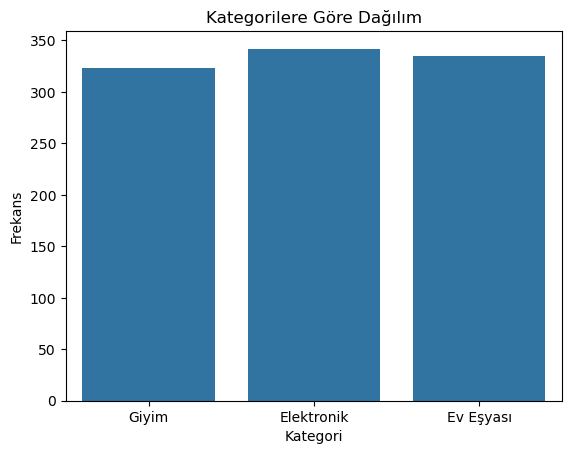

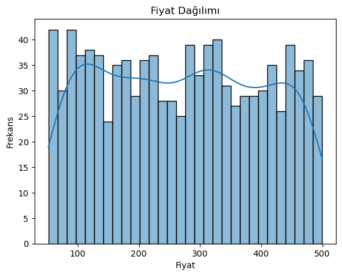

```python
import matplotlib.pyplot as plt
import seaborn as sns

# 1. Nitel değişken görseli
sns.countplot(x='kategori', data=df)
plt.title("Kategorilere Göre Dağılım")
plt.xlabel("Kategori")
plt.ylabel("Frekans")
plt.show()

# 2. Nicel değişken görseli
sns.histplot(df['fiyat'], bins=30, kde=True)
plt.title("Fiyat Dağılımı")
plt.xlabel("Fiyat")
plt.ylabel("Frekans")
plt.show()
```

📌 Grafikler, değişkenlerin davranışını daha kolay okuyabilmemizi sağlar.

## 📉 Değişkenleri Tanımak İçin Basit Kontroller

```python
# Değişken tiplerini kontrol et
print(df.dtypes)

# Değişkenin benzersiz değeri kaç?
print("\nKategorik Değişken Benzersiz Sayısı:")
print(df['kategori'].nunique())

# Sürekli değişken için dağılım özetleri
print("\nFiyat Çeyrekleri:")
print(df['fiyat'].quantile([0.25, 0.5, 0.75]))
```

```
fiyat          float64
satis_adedi      int64
kategori        object
dtype: object

Kategorik Değişken Benzersiz Sayısı:
3

Fiyat Çeyrekleri:
0.25    156.1875
0.50    273.5600
0.75    384.9475
Name: fiyat, dtype: float64
```

✅ Bu kodlar, verinin yapısını anlamana yardımcı olur.

## 📚 Değişkenler Arası İlişki Kurma

Veri biliminin temel amacı budur:  
**Hangi X, Y'yi nasıl etkiliyor?**

```
Korelasyon Matrisi:
                 fiyat  satis_adedi
fiyat        1.000000     0.050369
satis_adedi  0.050369     1.000000
```

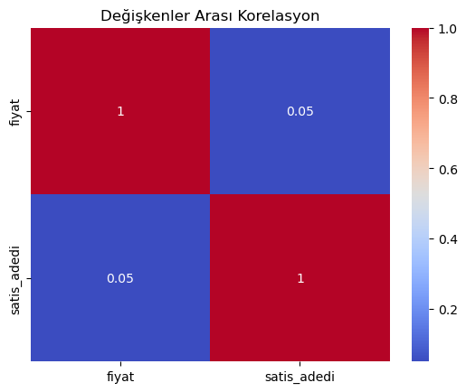

```python
# Korelasyon hesapla
df_korelasyon = df.select_dtypes(include=['number'])
print("Korelasyon Matrisi:\n", df_korelasyon.corr())

# Korelasyon matrisi görselleştirme
sns.heatmap(df_korelasyon.corr(), annot=True, cmap="coolwarm")
plt.title("Değişkenler Arası Korelasyon")
plt.show()
```